# GAI vignette

# Introduction to the GAI package

This vignette will illustrate the features available within the package by providing an example workflow on simulated data.

# Installing the Package from Source

In order to install the GAI package from source, the folder containing the source code must be downloaded from Github: https://github.com/calliste-fagard-jenkin/GAI

```r
#library(devtools, quietly = T)
#install_github("calliste-fagard-jenkin/GAI", quiet = F)
library(GAI)
```

# Preparing Data for the GAI Package

Let us begin by loading an example data set which is provided within the GAI package, and examining its structure. These data consist of a simulation from a mixture model with three broods, across 50 sites and 26 occasions (one survey every week from April to September, inclusive, for a given year).

```r
# For the pipe operator:
library(magrittr)
data("example_data")
head(example_data)
```

```
##   site occasion count    altitude
## 1    1        1     0  1.75733303
## 2    2        1    NA -1.62156062
## 3    3        1     0  1.32982955
## 4    4        1     2 -1.20585806
## 5    5        1     1  1.02254356
## 6    6        1    NA -0.00204768
```

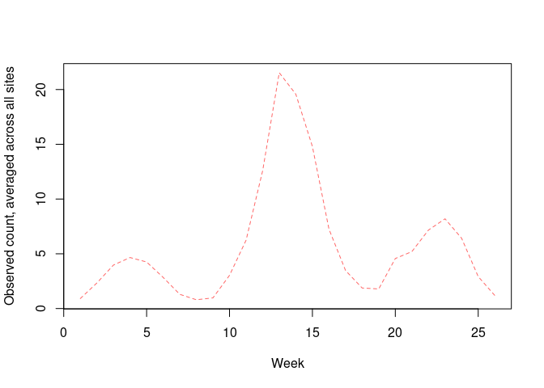

```r
# The GAI package comes with a handy function to convert data.frame data to
# a matrix of counts, to facilitate plotting. This function also checks if
# the survey has any missing occasions, so can be a useful way of sanitising
# a new dataset:
test_data <- extract_counts(example_data, returnDF = T)$matrix

# Plot the observed densities, averaged across all sites:
test_data %>% apply(2, mean, na.rm = T) %>%
  plot(x = 1:ncol(test_data), type = 'l', col = rgb(1, 0, 0, 0.6), lty = 2,
       xlab = 'Week', ylab = 'Observed count, averaged across all sites')
```

Each row in our input data.frame is used to store the result of the observed count at a given site on a given occasion. We assume that the interval between each occasion is fixed, and that sites are independent. The ‘site’, ‘occasion’ and ‘count’ columns must be given these precise names to allow the GAI package to recognise them. Missing observations can be listed with an NA entry.

Sites and occasions can have either character or numeric names. Because of this, the GAI package will assume occasions occurred in the order they first appear in the data frame. If no observations were collected for any sites on a given occasion, this occasion should still be included in the data.frame with NA entries for each site.

The fourth column ‘altitude’ represents a covariate (with standardised values), and will be used to illustrate how covariates can be included into different models available within the package.

# Fitting a Simple Model

The second part of the GAI model describes the distribution of observed counts of individuals at each site on a given occasion. The package includes Poisson (“P”), Negative Binomial (“NB”) and Zero-Inflated Poisson (“ZIP”) as options for this distribution.

```r
# We can load the true parameter values of the simulated data set from the
# GAI package, to more easily find starting parameter values for this example:
data("example_par")

# The 'options' argument of the fit_GAI function is how we specify the
# specific model we'd like the package to fit. For mixture and stopover models
# we can specify if each brood should be modelled to have the same standard
# deviation, and the number of broods our model should use:
my_options <- list(B = 3, shared_sigma = T)

# In the case of a spline-based model, the package needs to know the number of
# degrees of freedom and the degree of the splines we want to use:
options_for_splines <- list(df = 20, degree = 3)

# The fit_GAI function includes a 'verbose'  option, which prints the value of
# the negative log-likelihood at each iteration, and also the option to
# estimate the hessian matrix of the parameters, to obtain their
# variance covariance matrix:
my_mixture_GAI <- fit_GAI(start = example_par,
                          DF = example_data, a_choice = "mixture",
                          dist_choice = "ZIP", options = my_options,
                          verbose = T, hessian = T)
```

```
## negative log likelihood for iteration 1 is 2747.375
## negative log likelihood for iteration 2 is 1949.516
## negative log likelihood for iteration 3 is 1949.362
## final negative log likelihood value is 1949.361
## performing final iteration to find hessian
```

```r
# Print the MLEs to show the model has fitted correctly:
my_mixture_GAI$par
```

```
##        mu1        mu2        mu3      sigma         w1         w2   dist.par
##  1.4337144  2.2419175  2.1685968  0.6185839 -1.8263218  0.8410108  1.0687630
```

```r
# Not forgetting to add degrees of freedom and degree of splines information,
# and noting that specifying the number of broods will no longer have an
# effect:
my_spline_GAI <- fit_GAI(start = rep(0, 20), DF = example_data,
                         a_choice = "splines", dist_choice = "P",
                         options = options_for_splines, verbose = T,
                         hessian = T)

# Print the MLEs to show the model has fitted correctly:
my_spline_GAI$par
```

```
##  spline_par1  spline_par2  spline_par3  spline_par4  spline_par5  spline_par6
##  -0.74459183  -1.13888097   0.05605385   0.29477103  -0.28232268  -1.10391896
##  spline_par7  spline_par8  spline_par9 spline_par10 spline_par11 spline_par12
##  -0.19763237  -0.48065819   0.69275871   1.54254613   1.85688387   0.44059246
## spline_par13 spline_par14 spline_par15 spline_par16 spline_par17 spline_par18
##  -0.14966276  -0.73667369  -0.50787230   1.76684715  -0.49802746   0.60068050
## spline_par19 spline_par20
##  -1.25445441  -0.25760822
```

If an incorrect number of starting values is given to fit_GAI, an error will be raised, and a printout will indicate the parameter starting values that fit_GAI expects. The order of these starting values is important, and matches the order of the output fit_GAI produces in this scenario. This feature should be used to avoid making mistakes when unsure of how many parameters a model specification will require. Confusingly, NA values are not allowed as starting values, but functionality exists within the code to aid in finding reasonable starting values, which is outlined later in this vignette.

It’s worth noting that multiple numerical methods exist for finding the MLEs of the GAI model. The package uses the ‘optim’ function which makes use of the “Nelder-Mead” algorithm by default, but this can be changed to other options, such as “BFGS” or “SANN” (simulated annealing) by passing in method = “SANN” (for example) as an argument to fit_GAI.

```r
# We cut off some of our starting parameters on purpose, to cause the exception
# to be raised:
try({my_mixture_GAI <- fit_GAI(start = example_par[1:3], DF = example_data,
                               a_choice = "mixture", dist_choice = "ZIP",
                               options = my_options, verbose = T,
                               hessian = T)}, silent = T)
```

```
## [1] "Incorrect number of parameters supplied. Please submit something similar to:"
##      mu1      mu2      mu3    sigma       w1       w2 dist.par
##       NA       NA       NA       NA       NA       NA       NA
```

# Including Covariates

Models using ‘mixture’ and ‘stopover’ seasonal flight patterns are able to include covoariates on the values of the means, disperisions and weights for their normal distribution components.

Covariates can be included either as a general formula, which will apply to all broods, or be specified individually for each brood. Covariates for the normal components should be specified by adding a ‘mu_formula’, ‘sigma_formula’, or ‘w_formula’ to the ‘options argument’, for the mean, standard deviation, and for weights of each component, respectively.

When specifying covariate formulae one by one for each brood, we have the option of giving completely different formulae for each brood, or using NULL to specify that no covariates should be fitted for a given brood. Because of this flexibility, it is good practice to ensure the list of formulae always has the same number of elements as the number of broods specified. If more formulae are specified than there are broods, these extra formulae will simply be ignored.

```r
# To specify a formula which will be identical for each brood,
general_options <- list(B = 3, shared_sigma = T,
                        mu_formula = formula(~altitude))

# To be able to fit brood-specific covariate options for the standard deviations
# we require the standard deviation to be estimated individually for each brood,
# and so we set shared_sigma = F.
brood_specific_options <- list(B = 3, shared_sigma = F,
                               sigma_formula =
                                 list(NULL,                     # for brood 1
                                      formula(~altitude),       # for brood 2
                                      formula(~I(altitude^2)))) # for brood 3

# The distributional parameter we had previously for the ZIP (Zero-Inflated
# Poisson) distribution will disappear now that we're fitting a simple
# Poisson. However, we are also adding a covariate formula which will require
# one additional parameter. We'll give this a starting value of 0, which
# reflects an a priori belief that the covariate has no effect. To do this,
# we simply replace the final value of example par with 0, since distributional
# parameters are placed at the end of the parameter vector, and covariate are
# placed after these, when they are present:
general_fit_start <- example_par[1:(length(example_par) - 1)] %>% c(0)

# Having specified our covariate formulae, we can fit the model in exactly the
# same way as before:
general_fit <- fit_GAI(start = general_fit_start, DF = example_data,
                       a_choice = "mixture", dist_choice = "P",
                       options = general_options, hessian = T)

# Because these covariate data are dummies, we expect the fitted value to be
# very close to zero:
general_fit$par
```

```
##           mu1           mu2           mu3         sigma            w1
##  1.4321946354  2.2380852400  2.1784445351  0.6017422656 -1.7864346889
##            w2        mu.cov
##  0.8494187230  0.0002585895
```

```r
# To make the starting values for the new model, we steal the known values from
# the example_par vector (using the shared standard deviation across broods as
# the estimate for each brood individually). We then also add two 0s as our
# starting values for the covariate parameters
brood_specific_start = c(example_par[c(1:3, rep(4, 3), 5:6)], rep(0, 2))
brood_specific_fit <- fit_GAI(start = brood_specific_start,
                              DF = example_data, a_choice = "mixture",
                              dist_choice = "P", hessian = T,
                              options = brood_specific_options)
# Checking the MLEs:
brood_specific_fit$par
```

```
##         mu1         mu2         mu3      sigma1      sigma2      sigma3
##  1.43263822  2.23764857  2.17786835  0.62588867  0.59060074  0.65178441
##          w1          w2  sigma2.cov  sigma3.cov
## -1.76103674  0.85374271  0.01316131  0.01667243
```

```r
# A quick example to show a stopover model with the same options:
general_fit_stopover <- fit_GAI(start = c(general_fit_start, 0),
                                DF = example_data, a_choice = "stopover",
                                dist_choice = "P", options = general_options)

general_fit_stopover$par
```

```
##           mu1           mu2           mu3         sigma            w1
##  1.1540188696  2.2103537788  2.2013881150  0.3832084168 -1.7603532323
##            w2        mu.cov           phi
##  0.7562076768  0.0005076218 -0.0584397238
```

```r
brood_specific_stopover <- fit_GAI(start = c(brood_specific_start, 0),
                                   DF = example_data, a_choice = "stopover",
                                   dist_choice = "P",
                                   options = brood_specific_options)

brood_specific_stopover$par
```

```
##         mu1         mu2         mu3      sigma1      sigma2      sigma3
##  1.10670903  2.23424908  2.17949773  0.54391311  0.42538036  0.58692878
##          w1          w2  sigma2.cov  sigma3.cov         phi
## -1.72071892  0.97000749  0.04325090 -0.04385203 -0.23252762
```

```r
# And of course, we could also fit covariates to the simple univolitine case
# (although not for weights):
univ_options <- list(B = 1, sigma_formula = formula(~altitude))
univoltine_fit <- fit_GAI(start = c(2.2, 1, 0, 0), DF = example_data,
                          a_choice =  "stopover", options = univ_options)

univoltine_fit$par
```

```
##         mu      sigma  sigma.cov        phi
## 2.38741221 1.71805590 0.04216634 1.43889098
```

It should be noted that the GAI package comes with no methods for interpolating missing covariate values. Because of this, any NA covariate values in data.frame objects passed to fit_GAI will cause an error to be outputted to the console. The GAI package only supports ‘spatial’ covariates, that is, covariates whose values vary only by site, and are identical for every single sampling occasion, for a given site. Supplying time-varying covariates to fit_GAI will similarly lead to an error being thrown.

```r
example_NA <- example_time_varying <- example_data

# Turn roughly 5% of our altitude data to NA values:
indices <- example_NA$altitude %>% length %>% rbinom(size = 1, prob = 0.05)
example_NA$altitude[indices %>% as.logical] <- NA

# Turn our altitude data into a time-varying covariate by making it a function
# of the occasion:
example_time_varying$altitude <- example_data$altitude * example_data$occasion

# Trying to fit a covariate model with these new data will throw the relevant
# errors:
error_fit <- try(fit_GAI(start = general_fit_start, DF = example_NA,
                         a_choice = "mixture", dist_choice = "P",
                         options = general_options, hessian = T))
```

```
## Error in design_matrix(DF, formulas) : Covariate values cannot include NA
```

```r
# Trying to fit with a time-varying formula:
error_fit <- try(fit_GAI(start = general_fit_start, DF = example_time_varying,
                         a_choice = "mixture", dist_choice = "P",
                         options = general_options, hessian = T))
```

```
## Error in get_cov_skeleton_and_DM("mu", options, DF, B, skeleton, DMs) :
##   Covariate values must vary by site only, and not through time
```

# Finding Starting Values

The fit_GAI function expects all starting values to be given on this link scale, which can make using our intuition or knowledge of our data very difficult to produce good starting values. To remedy this, the transform_starting_values function can be used to transform parameter guesses on the ‘real world’ scale to the link scale.

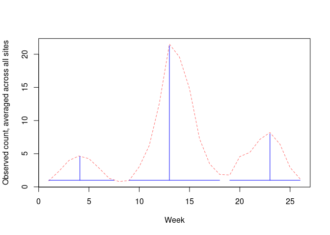

```r
# Let's produce a slightly 'annotated' version of the plot of observed counts
# we had before. We'll add in some lines where we think the mean brood arrival
# times are, and add in horizontal lines to try to estimate thw standard
# deviation of each brood's arrivals:
test_data %>% apply(2, mean, na.rm = T) %>%
  plot(x = 1:ncol(test_data), type = 'l', col = rgb(1, 0, 0, 0.6), lty = 2,
       xlab = 'Week', ylab = 'Observed count, averaged across all sites')

plot.col <- 'blue'
plot.base <- 1

# Mean brood arrival lines:
lines(rep(4.1, 2), c(plot.base, 4.6), col = plot.col)
lines(rep(13.0, 2), c(plot.base, 21.3), col = plot.col)
lines(rep(23.0, 2), c(plot.base, 8), col = plot.col)

# Mean brood dispersion lines:
lines(c(1, 7.5), rep(plot.base, 2), col = plot.col)
lines(c(9, 18), rep(plot.base, 2), col = plot.col)
lines(c(19, 26), rep(plot.base, 2), col = plot.col)
```

```r
# The length of the three horizontal bars that measure the width of our broods:
brood_widths <- c(6.5, 9, 7)

# Using a very rough rule of thumb that 95% of data in a normal distribution are
# found within 1.96 standard deviations from the means, we use the half width of
# our bars as an estimate of two sigma:
sigma_guesses <- brood_widths / 4

# Our guesses for the means can simply be read off of the lines of code that
# produced the plot:
mu_guesses <- c(4.1, 13, 23)

# To guess the weights, we make the crude assumption that the height of the peak
# of a brood relative to the others is roughly propoprtional to the percentage
# of the population that finds itself in this brood:
w_guesses <- c(4.6 - plot.base, 21.3 - plot.base, 8 - plot.base) %>%
  sum_to_one
```

Let’s consider our brood_specific_fit once more, but using the transform_starting_values function to obtain better starting values, without knowing the distribution our data came from. The transform_starting_values function will assume that 0 is a reasonable starting value for all covariate parameters and spline parameters, which usually leads to numerically sound estimation of the MLEs. However, if covariates aren’t normalised, and have large magnitude, this won’t be the case.

```r
# We create a list of starting values for parameters with the same structure
# as the options argument for fit_GAI:
my_starting_guesses <- list(mu = mu_guesses, sigma = sigma_guesses,
                            w = w_guesses)

# Note: When a ZIP or NB model is used, we can also include a guess for the
# distributional parameter by adding in a dist.par entry to this list, and
# additionally a retention probability 'phi' can be added for stopover models
new_brood_specific_start <-
  transform_starting_values(starting_values = my_starting_guesses,
                            a_choice = "mixture", dist_choice = "P",
                            options = brood_specific_options,
                            # When covariates are included in the model, we
                            # need to include the data.frame of observations and
                            # covariate values, or the GAI package won't be able
                            # to figure out how many parameters the model
                            # specification requires. This can be omitted for
                            # non-covariate-including models
                            DF = example_data)

# Let's print these new starting values, and refit the model:
print(new_brood_specific_start)
```

```
##        mu1        mu2        mu3     sigma1     sigma2     sigma3         w1
##  1.4109870  2.1860513  2.3025851  0.4855078  0.8109302  0.5596158 -2.0259529
##         w2 sigma2.cov sigma3.cov
##  1.0647107  0.0000000  0.0000000
```

```r
new_brood_specific_fit <- fit_GAI(start = new_brood_specific_start,
                                  DF = example_data, a_choice = "mixture",
                                  dist_choice = "P", hessian = T,
                                  options = brood_specific_options)
# Checking the MLEs:
new_brood_specific_fit$par
```

```
##         mu1         mu2         mu3      sigma1      sigma2      sigma3
##  1.41500508  2.24574295  2.18193605  0.65056697  0.59163927  0.60921230
##          w1          w2  sigma2.cov  sigma3.cov
## -1.76708274  0.86885953  0.01918536  0.07723517
```

# Using Bootstraps

Bootstraps in the GAI package are available in two options. The first option will resample sites (and their covariate values) from the observed data set, refitting the model each time it does this. It then extracts the bootstrap distribution of estimated site superpopulation sizes and parameter estimates to create a quantile method confidence interval for these. Because this type of bootstrap can be incredibly computionally expensive, functionality has been provided to do these calculations in parallel.

The second method of bootstrapping involves resampling parameter values from their asymptotic multivariate normal distribution. This involves a numerical estimate of the Information matrix, and so is only available if a model has been fitted with the hessian = TRUE option in fit_GAI.

The second type of bootstrap runs considerably faster, and is likely to be the only available option when many sites or covariates have been included, due to computational constrains. However, it should be noted that the first type typically produces intervals with coverage closer to the target, as it has no dependence on asymptotic properties or estimates of the Information matrix.

Bootstraps can be produced for transformed covariates, for models with and without covariates, in both the refit the model, and the resample the MLEs case.

```r
# To produce a bootstrap, we must specify if we wish to refit the model
# (determining the type of bootstrap fitted), as well as the number of
# bootstrap resamples we would like to use (R):
general_fit_bootstrap <- bootstrap(general_fit, R = 500, refit = F,
                                   alpha = 0.01, transform = T)
# The more time-consuming bootstrap can be fitted in parallel, with a chosen
# number of cores. If this is not specified, the default number of cores
# will be one less than the number available on the computer, so this must
# always be specified if running models on a large server:
refitting_bootstrap <- bootstrap(general_fit, R = 9, refit = T, parallel = T,
                                 cores = 3, alpha = 0.01, transform = T)
```

The bootstraps output contains raw values from each iteration of the estimated parameter values, the flight path densities for each site and occasion, the estimated site totals (site superpopulations), and the average estimated site total. The $1 - \alpha$ confidence intervals are available in the $par, $sites and $index elements of the bootstrap output for the parameters, individual site totals and average site total, respectively:

```r
# Taking a look at the results of the 'refit the model at each iteration'
# style of bootstrap:
refitting_bootstrap$par
```

```
##           [,1]     [,2]     [,3]     [,4]      [,5]      [,6]
## 0.5%  4.069241 13.46672 22.24305 1.766466 0.1353585 0.5719715
## 99.5% 4.262342 13.62510 22.48841 1.856965 0.1569945 0.6147956
```

# Model Outputs

The GAI package comes with some simple functionality for summarising models, as well as more detailed outputs, which will be covered in more detail. The standard R ‘summary’ function can be used to see the model’s AIC, average estimate site total across all sites, and also the MLEs for all model parameters.

```r
# Get a basic summary of the model outputs:
summary(my_mixture_GAI)
```

```
## Maximum Likelihood Estimates (MLEs):
##
##      mu1      mu2      mu3    sigma       w1       w2 dist.par
##   1.4340   2.2420   2.1690   0.6186  -1.8260   0.8410   1.0690
##
##
## MLE Standard Errors:
##
##      mu1      mu2      mu3    sigma       w1       w2 dist.par
## 0.019520 0.009342 0.007613 0.011750 0.040660 0.033120 0.081910
##
##
## Akaike's Information Criterion (AIC): 3912.722
##
## Average estimated site super-population size: 109.45
```

```r
# We can also obtain the AIC on its own using the standard AIC R function if
# we aren't interested in producing the rest of the summary:
AIC(my_mixture_GAI)
```

```
## [1] 3912.722
```

The output of the fit_GAI function is a list with a few important elements. The ‘par’ element gives named estimates of the MLEs for the model parameters, with ‘value’ giving the value of the negative log likelihood evaluated at the MLEs. ‘counts’, ‘convergence’, ‘message’ and ‘hessian’ are all standard outputs given by the optim function with details on the numerical process of estimating the MLEs. ‘spline_specs’ contains the user-specified options for fitting splines, and will be an empty list for mixture and stopover models. ‘dist_choice’ and ‘a_choice’ contain the count distribution and flight path distributions, respectively. Skeleton contains the skeleton list of parameter values that the package uses to fit the model, with ‘options’ being the list of options passed to fit_GAI. ‘maxiter’ refers to the maximum number of iterations used to estimate the MLEs of ZIP and NB models. ‘A’ and ‘N’ contain the matrix of estimated seasonal densities at each site and occasion, and the vector of estimated site totals, respectively. ‘DMs’ contains the list of design matrices used by the GAI package to include the selected covariate formulas in the model. ‘obs’ contains the count observations in matrix form, with sites as rows and occasions as columns. This is the same format as for ‘A’. ‘DF’ contains the original data.frame supplied to fit_GAI, and finally, ‘tol’ specififies the stopping condition used for the model (an epsilon such that during an iterative process for fitting a ZIP or NB model, a difference of less than epsilon in the negative log likelihood between two iterations causes the process to terminate).

# Transforming Parameter Estimates

Numerical solvers that attempt to find the MLEs must be able to perform guesses anywhere on the real scale. This causes issues with certain parameters which can only take on values in very particular ranges, such as probabilities which must always be between 0 and 1, for example. Further to this, the estimation of values such as mean arrival times for broods can be unidentifiable if specified ambiguously. In this example, unless we force the mean for the second brood to be greater than that for the first (and so forth), then multiple sets of parameters could give the same maximal value of the log likelihood. For these reasons, the GAI package uses link functions to map between the real line on which we make parameter value guesses during fitting, and the ‘parameter space line’, where all parameters are within the correct bounds.

The transform_output function within the GAI package uses model settings stored in the fitted model object to apply these link functions automatically, making sure that the effect of covariates has also been taken into account.

```r
# We can create a data.frame with custom covariate values, or reuse values that
# we observed during the survey:
DF_to_transform <- data.frame(altitude = c(-100, 0, 100))
DF_to_transform <- general_fit$DF[1:3,]

# The transfor_output function deals with all the covariate formulas and link
# functions by using the information contained in the fitted model object:
transform_output(general_fit, DF_to_transform)
```

```
##        mu1      mu2      mu3   sigma1        w1       w2
## 1 4.189784 13.56941 22.40598 1.825296 0.1435104 0.599924
## 2 4.186124 13.55756 22.38641 1.825296 0.1435104 0.599924
## 3 4.189320 13.56791 22.40350 1.825296 0.1435104 0.599924
```

```r
# When no covariates were included in the model, a blank data.frame, or no
# data.frame at all can be used to only provide the transformed values:
transform_output(my_mixture_GAI)
```

```
##          mu1      mu2      mu3   sigma1       w1        w2  dist.par
## [1,] 4.19425 13.60561 22.35161 1.856297 0.138677 0.6017875 0.7443616
```

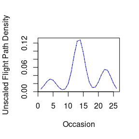

```r
# We can also use this function to get out the a_func matrix for a set of
# covariate values:
A <- transform_output(general_fit, DF_to_transform, provide_A = T)$A
matplot(t(A), type = 'l', col = c("blue", "darkblue", "darkgrey"),
        ylab = "Unscaled Flight Path Density", xlab = "Occasion")
```

```r
# It's important to include all covariates exactly as they were named in the
# call to fit_GAI, otherwise an error will be thrown, giving the name of the
# missing covariate.
try(transform_output(brood_specific_fit, data.frame(altiitude = c(-10, 0, 10))))
```

```
## Error in eval(predvars, data, env) : object 'altitude' not found
```

```r
# NA covariate values will throw an error, as always:
try(transform_output(brood_specific_fit, data.frame(altitude = c(NA, 0, 10))))
```

```
## Error in design_matrix(DF, current_formula) :
##   Covariate values cannot include NA
```

# Plotting Fitted Curves

The standard R plot function can be used to produce simple plots of the flight path of a fitted model. Optionally, either the flight path for each site can be included as a separate curve on the same graph, or a smooth can be plotted instead. This smooth averages through the different values observed at each site, at a set of quantiles that can be specified by the user. The default behaviour produces plots for the median density ocross sites for a given occasion, as well as the 5th and 95th quantiles for flight path density.

To better compare the relative abundance at each site throughout the year, especially when covariates have been included in the model, it can be useful to scale the flight path curve of each site by the estimated site total. This can be done by setting scale_by_N = TRUE in the call to the ‘plot’ function.

If custom colours are to be used by the plotting function, the colour palette can be passed to the ‘plot’ function as a vector of integers or character colour hex values using the ‘colours’ argument.

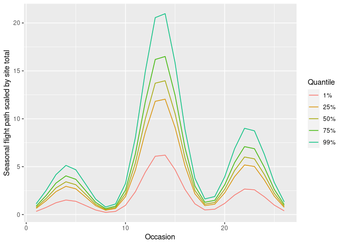

```r
colours <- c("#33FFF9", "#33A8FF", "#4233FF")

# The default behaviour will use quantiles = c(0.05, 0.5, 0.95), and therefore
# will not plot all sites individually.
plot(general_fit, scale_by_N = T, quantiles = c(0.01, 0.25, 0.5, 0.75, 0.99))
```

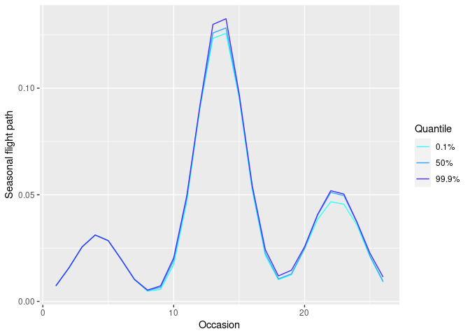

```r
# For the sake of demonstration, a plot with manual colours, with no scaling:
plot(brood_specific_fit, scale_by_N = F, quantiles = c(0.001, 0.5, 0.999),
     colours = colours)
```